# portableStim: Getting Started

Carlos Antonio Rodriguez-Saltos

2018-06-05

The portableStim packages allows the user to generate acoustic presentations based on a single source audio file. The audio file is repeated several times, according to user specifications, and silence gaps are placed in between repeates. The silence gaps may be constant in duration or they may be drawn from a random, Poisson distribution, depending on user specifications.

A typical presentation generated using portableStim will have the following structure:

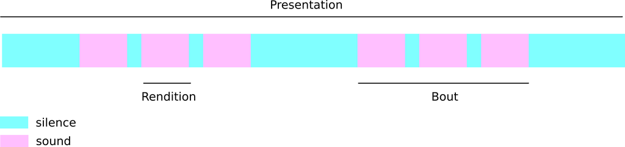

Structure of an acoustic presentation generated using portableStim

## The genTrain function

The core function of portableStim is genTrain(). Please check the function documentation to see all the arguments that can be specified. The name of a soundfile can be passed to genTrain() as well as the name of the output presentation. genTrain() builds a schema for the presentation based on user specifications and then calls the command line program SoX to manipulate the sound file. Using SoX significantly reduces the time required to generate the presentation file, as opposed to using utilities that load sound files into an R environment.

## Installing SoX

SoX, the “Swiss Army Knife of sound processing programs”, is a cross-platform command-line utility. SoX must be installed by the user before using portableStim. For instructions on how to install SoX on your platform, please refer to the SoX website: http://sox.sourceforge.net/

## tico - our example source file

In the following examples, we will use the “tico” sound datum provided by the package seewave. This sound corresponds to the song of a Rufous-collared Sparrow (*Zonotrichia capensis*) about 1.8 seconds long.

portableStim requires a sound file as input, rather than a data object. portableStim, however, recognizes when the user calls “tico” and it automatically saves the data object into a temporary file.

“tico” can be called in portableStim by setting the “sound”" argument in genTrain() to “#tico#”.

Here is a sonogram of “tico”:

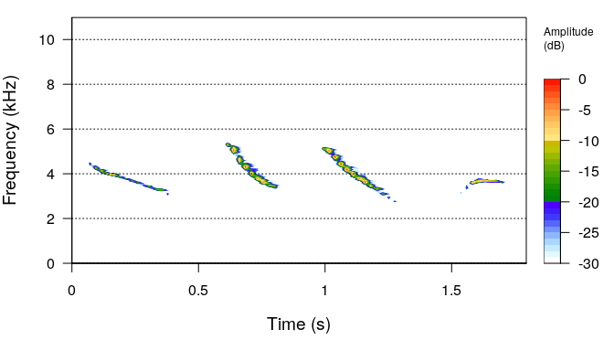

```r
data(tico, package = "seewave")
seewave::spectro(tico)
```

```r
library(portableStim)

# Create a temporary file where to store the output presentation
outputf <- tempfile(fileext = ".wav")

# Generate presentation
#genTrain(
 # sound = "#tico#",  # Source sound
  #bout.length = 60,  # Length of the bout in seconds
  #intRend.type = "constant",  # Type of interval. Can be constant or random.
  #intRend.length = 1,  # Length of the silence intervals between renditions, in seconds
  #output = outputf,  # Output file
  # The following arguments must be specified for this instane of genTrain() to work. It will be explained later, when we create repetitions of a bout
  #tpres = 10,
  #intBout.type = "constant",
  #nbout= 1
#)

# Plot sonogram of bout
#wavef <- tuneR::readWave(outputf)
#seewave::spectro(wave = wavef)
```

## Generating a presentation with constant silence intervals

To generate a presentation with constant silence intervals, all of the following parameters must be specified: 1) total time of the presentation, 2) length of the silence interval, and at least one of the following parameters: 1) number of bouts, 2) length of each bout.

In the following example, we will generate a presentation with the following characteristics: - presentation time: 1 min - interval between bouts: 5 sec - bout length: 5 sec

```r
library(portableStim)

# Create a temporary file where to store the output presentation
outputf <- tempfile(fileext = ".wav")

# Generate presentation
genTrain(
  sound = "#tico#",
  tpres = 60,  # Presentation time in seconds
  bout.length = 5,  # Length of the bout in seconds
  intBout.type = "constant",  # Type of interbout interval
  intBout.length = 5,  # Length of the interbout interval, in seconds
  intRend.type = "constant",
  intRend.length = 1,
  output = outputf
)
```

```
#> $rendtion.gaps
#> [1] 0 1
#>
#> $bout.gaps
#> [1] 5 5 5 5 5 5
```

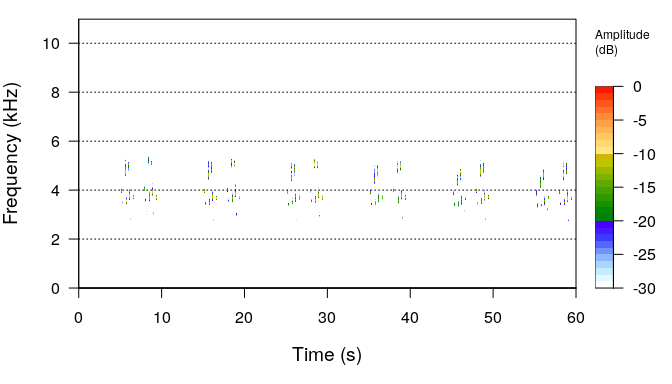

```r
# Plot sonogram of presentation
wavef <- tuneR::readWave(outputf)
seewave::spectro(wave = wavef)
```

Key in telling genTrain() that the bout intervals are constant is the argument “intBout.type”. This argument is similar to “intRend.type, which specifies the type of intervals between renditions within a bout.

## Generating a presentation with random intervals